# Running the Leiden algorithm with R

S. Thomas Kelly

2019-02-04

## Clustering with the Leiden Algorithm in R

This package allows calling the Leiden algorthm for clustering on an igraph object from R. See the Python and Java implementations for more details:

https://github.com/CWTSLeiden/networkanalysis

https://github.com/vtraag/leidenalg

## Install

This package requires the ‘leidenalg’ and ‘igraph’ modules for python (2) to be installed on your system. For example:

`pip install leidenalg igraph`

If you do not have root access, you can use `pip install --user` or `pip install --prefix` to install these in your user directory (which you have write permissions for) and ensure that this directory is in your PATH so that Python can find it.

The ‘devtools’ package will be used to install ‘leiden’ and the dependancies (igraph and reticulate). To install the development version:

```r
if (!requireNamespace("devtools"))
    install.packages("devtools")
devtools::install_github("TomKellyGenetics/leiden")
```

The current release on CRAN can be installed with:

```r
install.packages("leiden")
```

```r
library("leiden")
```

## Usage

### Running the Leiden algorithm in R

First set up a compatible adjacency matrix:

```r
adjacency_matrix <- rbind(cbind(matrix(round(rbinom(4000, 1, 0.8)), 20, 20), matrix(round(rbinom(4000, 1, 0.3)), 20, 20), matrix(round(rbinom(400, 1, 0.1)), 20, 20)),
                          cbind(matrix(round(rbinom(400, 1, 0.3)), 20, 20), matrix(round(rbinom(400, 1, 0.8)), 20, 20), matrix(round(rbinom(4000, 1, 0.2)), 20, 20)),
                          cbind(matrix(round(rbinom(400, 1, 0.3)), 20, 20), matrix(round(rbinom(4000, 1, 0.1)), 20, 20), matrix(round(rbinom(4000, 1, 0.9)), 20, 20)))
str(adjacency_matrix)
```

```
#>  num [1:60, 1:60] 1 1 1 1 1 1 1 1 1 1 ...
```

```r
dim(adjacency_matrix )
```

```
#> [1] 60 60
```

An adjacency matrix is any binary matrix representing links between nodes (column and row names). It is a directed graph if the adjacency matrix is not symmetric.

```r
library("igraph")
rownames(adjacency_matrix) <- 1:60
colnames(adjacency_matrix) <- 1:60
graph_object <- graph_from_adjacency_matrix(adjacency_matrix, mode = "directed")
graph_object
```

```
#> IGRAPH 52b6491 DN-- 60 1536 --
#> + attr: name (v/c)
#> + edges from 52b6491 (vertex names):
#>  [1] 1->1  1->2  1->3  1->4  1->6  1->7  1->8  1->9  1->10 1->12 1->13
#> [12] 1->14 1->15 1->16 1->17 1->18 1->19 1->20 1->24 1->26 1->28 1->29
#> [23] 1->31 1->32 1->33 1->38 1->43 1->44 1->53 1->58 1->59 2->1  2->3
#> [34] 2->4  2->5  2->6  2->7  2->8  2->9  2->11 2->12 2->13 2->14 2->15
#> [45] 2->16 2->18 2->20 2->22 2->26 2->34 2->36 2->44 2->51 3->1  3->4
#> [56] 3->5  3->6  3->7  3->8  3->9  3->10 3->11 3->12 3->13 3->14 3->16
#> [67] 3->17 3->18 3->19 3->20 3->22 3->29 3->31 3->33 3->35 3->39 3->40
#> [78] 3->56 3->60 4->1  4->2  4->3  4->4  4->5  4->6  4->7  4->9  4->10
#> + ... omitted several edges
```

This represents the following graph structure.

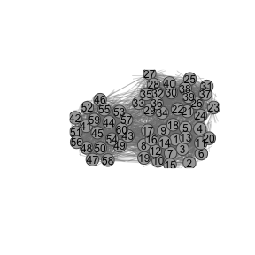

```r
library("devtools")
install_github("TomKellyGenetics/igraph.extensions")
library("plot.igraph")
plot_directed(graph_object, cex.arrow = 0.3, col.arrow = "grey50")
```

This can be a shared nearest neighbours matrix derived from a graph object.

```r
library("igraph")
adjacency_matrix <- igraph::as_adjacency_matrix(graph_object)
```

Then the Leiden algorithm can be run on the adjacency matrix.

```r
partition <- leiden(adjacency_matrix)
table(partition)
```

```
#> partition
#>  1  2  3
#> 20 20 20
```

Here we can see partitions in the plotted results. The nodes that are more interconnected have been paritioned into separate clusters.

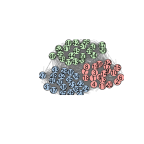

```r
library("RColorBrewer")
node.cols <- brewer.pal(max(partition),"Pastel1")[partition]
plot_directed(graph_object, cex.arrow = 0.3, col.arrow = "grey50", fill.node = node.cols)
```

### Running Leiden with arguments passed to leidenalg

Arguments can be passed to the leidenalg implementation in Python:

```r
#run with defaults
  partition <- leiden(adjacency_matrix)


#run with ModularityVertexPartition"
  partition <- leiden(adjacency_matrix, partition_type = "ModularityVertexPartition")


#run with resolution parameter
  partition <- leiden(adjacency_matrix, resolution_parameter = 0.95)
```

In particular, the resolution parameter can tue the numberof clusters to be detected.

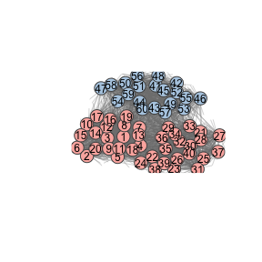

```r
partition <- leiden(adjacency_matrix, resolution_parameter = 0.5)
node.cols <- brewer.pal(max(partition),"Pastel1")[partition]
plot_directed(graph_object, cex.arrow = 0.3, col.arrow = "grey50", fill.node = node.cols)
```

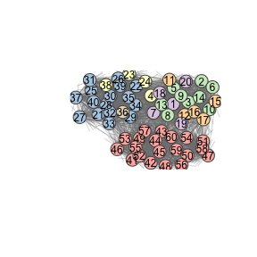

```r
partition <- leiden(adjacency_matrix, resolution_parameter = 1.8)
node.cols <- brewer.pal(max(partition),"Pastel1")[partition]
plot_directed(graph_object, cex.arrow = 0.3, col.arrow = "grey50", fill.node = node.cols)
```

See the documentation on the leidenalg Python module for more information: https://leidenalg.readthedocs.io/en/latest/reference.html

## Running on a Seurat Object

### Seurat version 2

To use Leiden with the Seurat pipeline for a Seurat Object `object` that has an SNN computed (for example with `Seurat::FindClusters` with `save.SNN = TRUE`). This will compute the Leiden clusters and add them to the Seurat Object Class.

```r
adjacency_matrix <- as.matrix(object@snn)
membership <- leiden(adjacency_matrix)
object@ident <- as.factor(membership)
names(test@ident) <- rownames(test@meta.data)
object@meta.data$ident <- as.factor(membership)
```

Note that this code is designed for Seurat version 2 releases.

### Seurat version 3 or later

For Seurat version 3 objects, the Leiden algorithm will be implemented in the Seurat version 3 package with `Seurat::FindClusters` and `algorithm = "leiden"`). See the documentation for these functions.